# Optimal Treatment Analysis

## Outcome Variable

**Outcome Variable:** whz

## Predictor Variables

**Intervention Variable:** predfeed3

**Adjustment Set:**

- arm
- sex
- month
- brthmon
- W_mage
- meducyrs
- feducyrs
- hhwealth_quart
- hfoodsec
- W_mhtcm
- W_mwtkg
- W_mbmi
- vagbrth
- W_gagebrth
- W_birthwt
- W_birthlen
- W_nrooms
- W_nchldlt5
- W_parity
- impfloor
- impsan
- safeh20
- delta_W_mage
- delta_meducyrs
- delta_feducyrs
- delta_hhwealth_quart
- delta_hfoodsec
- delta_W_mhtcm
- delta_W_mwtkg
- delta_W_mbmi
- delta_vagbrth
- delta_W_gagebrth
- delta_W_birthwt
- delta_W_birthlen
- delta_W_nrooms
- delta_W_nchldlt5
- delta_W_parity
- delta_impfloor
- delta_impsan
- delta_safeh20

## Stratifying Variables

The analysis was stratified on these variable(s):

- agecat
- studyid
- country

## Data Summary

| agecat | studyid | country | predfeed3 | n_cell | n |
| --- | --- | --- | --- | --- | --- |
| Birth | EE | PAKISTAN | 1 | 22 | 22 |
| Birth | EE | PAKISTAN | 0 | 0 | 22 |
| Birth | GMS-Nepal | NEPAL | 1 | 352 | 422 |
| Birth | GMS-Nepal | NEPAL | 0 | 70 | 422 |
| Birth | JiVitA-3 | BANGLADESH | 1 | 9638 | 10634 |
| Birth | JiVitA-3 | BANGLADESH | 0 | 996 | 10634 |
| Birth | JiVitA-4 | BANGLADESH | 1 | 89 | 97 |
| Birth | JiVitA-4 | BANGLADESH | 0 | 8 | 97 |
| Birth | MAL-ED | BANGLADESH | 1 | 164 | 202 |
| Birth | MAL-ED | BANGLADESH | 0 | 38 | 202 |
| Birth | MAL-ED | BRAZIL | 1 | 23 | 55 |
| Birth | MAL-ED | BRAZIL | 0 | 32 | 55 |
| Birth | MAL-ED | INDIA | 1 | 27 | 39 |
| Birth | MAL-ED | INDIA | 0 | 12 | 39 |
| Birth | MAL-ED | NEPAL | 1 | 14 | 25 |
| Birth | MAL-ED | NEPAL | 0 | 11 | 25 |
| Birth | MAL-ED | PERU | 1 | 145 | 218 |
| Birth | MAL-ED | PERU | 0 | 73 | 218 |
| Birth | MAL-ED | SOUTH AFRICA | 1 | 33 | 99 |
| Birth | MAL-ED | SOUTH AFRICA | 0 | 66 | 99 |
| Birth | MAL-ED | TANZANIA, UNITED REPUBLIC OF | 1 | 24 | 95 |
| Birth | MAL-ED | TANZANIA, UNITED REPUBLIC OF | 0 | 71 | 95 |
| 6 months | EE | PAKISTAN | 1 | 39 | 39 |
| 6 months | EE | PAKISTAN | 0 | 0 | 39 |
| 6 months | GMS-Nepal | NEPAL | 1 | 367 | 441 |
| 6 months | GMS-Nepal | NEPAL | 0 | 74 | 441 |
| 6 months | JiVitA-3 | BANGLADESH | 1 | 8500 | 9310 |
| 6 months | JiVitA-3 | BANGLADESH | 0 | 810 | 9310 |
| 6 months | JiVitA-4 | BANGLADESH | 1 | 76 | 88 |
| 6 months | JiVitA-4 | BANGLADESH | 0 | 12 | 88 |
| 6 months | MAL-ED | BANGLADESH | 1 | 191 | 233 |
| 6 months | MAL-ED | BANGLADESH | 0 | 42 | 233 |
| 6 months | MAL-ED | BRAZIL | 1 | 93 | 187 |
| 6 months | MAL-ED | BRAZIL | 0 | 94 | 187 |
| 6 months | MAL-ED | INDIA | 1 | 147 | 210 |
| 6 months | MAL-ED | INDIA | 0 | 63 | 210 |
| 6 months | MAL-ED | NEPAL | 1 | 113 | 227 |
| 6 months | MAL-ED | NEPAL | 0 | 114 | 227 |
| 6 months | MAL-ED | PERU | 1 | 176 | 270 |
| 6 months | MAL-ED | PERU | 0 | 94 | 270 |
| 6 months | MAL-ED | SOUTH AFRICA | 1 | 63 | 244 |
| 6 months | MAL-ED | SOUTH AFRICA | 0 | 181 | 244 |
| 6 months | MAL-ED | TANZANIA, UNITED REPUBLIC OF | 1 | 64 | 212 |
| 6 months | MAL-ED | TANZANIA, UNITED REPUBLIC OF | 0 | 148 | 212 |
| 24 months | EE | PAKISTAN | 1 | 20 | 20 |
| 24 months | EE | PAKISTAN | 0 | 0 | 20 |
| 24 months | GMS-Nepal | NEPAL | 1 | 322 | 384 |
| 24 months | GMS-Nepal | NEPAL | 0 | 62 | 384 |
| 24 months | JiVitA-3 | BANGLADESH | 1 | 4417 | 4833 |
| 24 months | JiVitA-3 | BANGLADESH | 0 | 416 | 4833 |
| 24 months | JiVitA-4 | BANGLADESH | 1 | 135 | 150 |
| 24 months | JiVitA-4 | BANGLADESH | 0 | 15 | 150 |
| 24 months | MAL-ED | BANGLADESH | 1 | 168 | 205 |
| 24 months | MAL-ED | BANGLADESH | 0 | 37 | 205 |
| 24 months | MAL-ED | BRAZIL | 1 | 79 | 152 |
| 24 months | MAL-ED | BRAZIL | 0 | 73 | 152 |
| 24 months | MAL-ED | INDIA | 1 | 139 | 202 |
| 24 months | MAL-ED | INDIA | 0 | 63 | 202 |
| 24 months | MAL-ED | NEPAL | 1 | 110 | 220 |
| 24 months | MAL-ED | NEPAL | 0 | 110 | 220 |
| 24 months | MAL-ED | PERU | 1 | 131 | 198 |
| 24 months | MAL-ED | PERU | 0 | 67 | 198 |
| 24 months | MAL-ED | SOUTH AFRICA | 1 | 60 | 228 |
| 24 months | MAL-ED | SOUTH AFRICA | 0 | 168 | 228 |
| 24 months | MAL-ED | TANZANIA, UNITED REPUBLIC OF | 1 | 54 | 184 |
| 24 months | MAL-ED | TANZANIA, UNITED REPUBLIC OF | 0 | 130 | 184 |

The following strata were considered:

- agecat: 24 months, studyid: EE, country: PAKISTAN
- agecat: 24 months, studyid: GMS-Nepal, country: NEPAL
- agecat: 24 months, studyid: JiVitA-3, country: BANGLADESH
- agecat: 24 months, studyid: JiVitA-4, country: BANGLADESH
- agecat: 24 months, studyid: MAL-ED, country: BANGLADESH
- agecat: 24 months, studyid: MAL-ED, country: BRAZIL
- agecat: 24 months, studyid: MAL-ED, country: INDIA
- agecat: 24 months, studyid: MAL-ED, country: NEPAL
- agecat: 24 months, studyid: MAL-ED, country: PERU
- agecat: 24 months, studyid: MAL-ED, country: SOUTH AFRICA
- agecat: 24 months, studyid: MAL-ED, country: TANZANIA, UNITED REPUBLIC OF
- agecat: 6 months, studyid: EE, country: PAKISTAN
- agecat: 6 months, studyid: GMS-Nepal, country: NEPAL
- agecat: 6 months, studyid: JiVitA-3, country: BANGLADESH
- agecat: 6 months, studyid: JiVitA-4, country: BANGLADESH
- agecat: 6 months, studyid: MAL-ED, country: BANGLADESH
- agecat: 6 months, studyid: MAL-ED, country: BRAZIL
- agecat: 6 months, studyid: MAL-ED, country: INDIA
- agecat: 6 months, studyid: MAL-ED, country: NEPAL
- agecat: 6 months, studyid: MAL-ED, country: PERU
- agecat: 6 months, studyid: MAL-ED, country: SOUTH AFRICA
- agecat: 6 months, studyid: MAL-ED, country: TANZANIA, UNITED REPUBLIC OF
- agecat: Birth, studyid: EE, country: PAKISTAN
- agecat: Birth, studyid: GMS-Nepal, country: NEPAL
- agecat: Birth, studyid: JiVitA-3, country: BANGLADESH
- agecat: Birth, studyid: JiVitA-4, country: BANGLADESH
- agecat: Birth, studyid: MAL-ED, country: BANGLADESH
- agecat: Birth, studyid: MAL-ED, country: BRAZIL
- agecat: Birth, studyid: MAL-ED, country: INDIA
- agecat: Birth, studyid: MAL-ED, country: NEPAL
- agecat: Birth, studyid: MAL-ED, country: PERU
- agecat: Birth, studyid: MAL-ED, country: SOUTH AFRICA
- agecat: Birth, studyid: MAL-ED, country: TANZANIA, UNITED REPUBLIC OF

### Dropped Strata

- agecat: Birth, studyid: EE, country: PAKISTAN
- agecat: 6 months, studyid: EE, country: PAKISTAN
- agecat: 24 months, studyid: EE, country: PAKISTAN

## Methods Detail

We’re interested in the causal parameters $E[Y_a]$ for all values of $a \in \mathcal{A}$. These parameters represent the mean outcome if, possibly contrary to fact, we intervened to set all units to have $A=a$. Under the randomization and positivity assumptions, these are identified by the statistical parameters $\psi_a=E_W[E_{Y|A,W}(Y|A=a,W)]$. In addition, we’re interested in the mean of $Y$, $E[Y]$ under no intervention (the observed mean). We will estimate these parameters by using SuperLearner to fit the relevant likelihood factors – $E_{Y|A,W}(Y|A=a,W)$ and $p(A=a|W)$, and then updating our likelihood fit using a joint TMLE.

For unadjusted analyses ($W=\{\}$), initial likelihoods were estimated using Lrnr_glm to estimate the simple $E(Y|A)$ and Lrnr_mean to estimate $p(A)$. For adjusted analyses, a small library containing Lrnr_glmnet, Lrnr_xgboost, and Lrnr_mean was used.

Having estimated these parameters, we will then use the delta method to estimate relative risks and attributable risks relative to a prespecified baseline level of $A$.

# Results Detail

## Results Plots

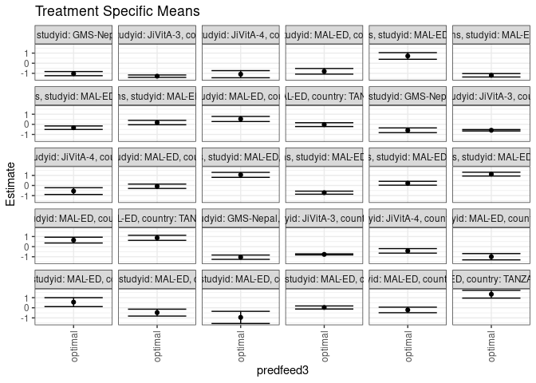

## Results Table

### Parameter: TSM

| agecat | studyid | country | intervention_level | baseline_level | estimate | ci_lower | ci_upper |
| --- | --- | --- | --- | --- | --- | --- | --- |
| Birth | GMS-Nepal | NEPAL | optimal | observed | -1.0431577 | -1.2567115 | -0.8296038 |
| Birth | JiVitA-3 | BANGLADESH | optimal | observed | -0.7653177 | -0.8206521 | -0.7099833 |
| Birth | JiVitA-4 | BANGLADESH | optimal | observed | -0.4179815 | -0.6407238 | -0.1952392 |
| Birth | MAL-ED | BANGLADESH | optimal | observed | -0.9983536 | -1.3112120 | -0.6854951 |
| Birth | MAL-ED | BRAZIL | optimal | observed | 0.5587974 | 0.1163797 | 1.0012150 |
| Birth | MAL-ED | INDIA | optimal | observed | -0.4772276 | -0.8186110 | -0.1358441 |
| Birth | MAL-ED | NEPAL | optimal | observed | -0.9505119 | -1.5514697 | -0.3495542 |
| Birth | MAL-ED | PERU | optimal | observed | 0.0310215 | -0.1197272 | 0.1817702 |
| Birth | MAL-ED | SOUTH AFRICA | optimal | observed | -0.2125766 | -0.4851926 | 0.0600394 |
| Birth | MAL-ED | TANZANIA, UNITED REPUBLIC OF | optimal | observed | 1.3416163 | 0.9592902 | 1.7239423 |
| 6 months | GMS-Nepal | NEPAL | optimal | observed | -0.5862751 | -0.8210819 | -0.3514684 |
| 6 months | JiVitA-3 | BANGLADESH | optimal | observed | -0.5863704 | -0.6542519 | -0.5184888 |
| 6 months | JiVitA-4 | BANGLADESH | optimal | observed | -0.5525710 | -0.8881538 | -0.2169883 |
| 6 months | MAL-ED | BANGLADESH | optimal | observed | -0.0762104 | -0.2911225 | 0.1387017 |
| 6 months | MAL-ED | BRAZIL | optimal | observed | 1.0530693 | 0.8068151 | 1.2993235 |
| 6 months | MAL-ED | INDIA | optimal | observed | -0.7107775 | -0.8607567 | -0.5607983 |
| 6 months | MAL-ED | NEPAL | optimal | observed | 0.2219806 | 0.0283243 | 0.4156368 |
| 6 months | MAL-ED | PERU | optimal | observed | 1.1247874 | 0.9366049 | 1.3129699 |
| 6 months | MAL-ED | SOUTH AFRICA | optimal | observed | 0.6474971 | 0.3610385 | 0.9339557 |
| 6 months | MAL-ED | TANZANIA, UNITED REPUBLIC OF | optimal | observed | 0.8706834 | 0.6209530 | 1.1204138 |
| 24 months | GMS-Nepal | NEPAL | optimal | observed | -1.0293301 | -1.2355680 | -0.8230923 |
| 24 months | JiVitA-3 | BANGLADESH | optimal | observed | -1.2842726 | -1.4029034 | -1.1656417 |
| 24 months | JiVitA-4 | BANGLADESH | optimal | observed | -1.0874195 | -1.4386150 | -0.7362240 |
| 24 months | MAL-ED | BANGLADESH | optimal | observed | -0.8026764 | -1.0807108 | -0.5246420 |
| 24 months | MAL-ED | BRAZIL | optimal | observed | 0.7169394 | 0.3870736 | 1.0468052 |
| 24 months | MAL-ED | INDIA | optimal | observed | -1.1970792 | -1.3652469 | -1.0289115 |
| 24 months | MAL-ED | NEPAL | optimal | observed | -0.3331543 | -0.5058065 | -0.1605022 |
| 24 months | MAL-ED | PERU | optimal | observed | 0.1789085 | -0.0394016 | 0.3972185 |
| 24 months | MAL-ED | SOUTH AFRICA | optimal | observed | 0.5325122 | 0.2781516 | 0.7868729 |
| 24 months | MAL-ED | TANZANIA, UNITED REPUBLIC OF | optimal | observed | -0.0279817 | -0.2180652 | 0.1621018 |

### Parameter: E(Y)

| agecat | studyid | country | intervention_level | baseline_level | estimate | ci_lower | ci_upper |
| --- | --- | --- | --- | --- | --- | --- | --- |
| Birth | GMS-Nepal | NEPAL | observed | observed | -1.0991706 | -1.2073693 | -0.9909719 |
| Birth | JiVitA-3 | BANGLADESH | observed | observed | -0.7798636 | -0.8022140 | -0.7575133 |
| Birth | JiVitA-4 | BANGLADESH | observed | observed | -0.4347423 | -0.6441144 | -0.2253701 |
| Birth | MAL-ED | BANGLADESH | observed | observed | -0.9411386 | -1.0895370 | -0.7927402 |
| Birth | MAL-ED | BRAZIL | observed | observed | 0.4316364 | 0.0969688 | 0.7663039 |
| Birth | MAL-ED | INDIA | observed | observed | -0.9779487 | -1.2664810 | -0.6894164 |
| Birth | MAL-ED | NEPAL | observed | observed | -0.7944000 | -1.1625222 | -0.4262778 |
| Birth | MAL-ED | PERU | observed | observed | -0.0335321 | -0.1564905 | 0.0894263 |
| Birth | MAL-ED | SOUTH AFRICA | observed | observed | -0.1588889 | -0.3845288 | 0.0667510 |
| Birth | MAL-ED | TANZANIA, UNITED REPUBLIC OF | observed | observed | 0.7996842 | 0.5874808 | 1.0118876 |
| 6 months | GMS-Nepal | NEPAL | observed | observed | -0.6198791 | -0.7206518 | -0.5191063 |
| 6 months | JiVitA-3 | BANGLADESH | observed | observed | -0.6040977 | -0.6286619 | -0.5795335 |
| 6 months | JiVitA-4 | BANGLADESH | observed | observed | -0.4110227 | -0.6122701 | -0.2097753 |
| 6 months | MAL-ED | BANGLADESH | observed | observed | -0.1304936 | -0.2625419 | 0.0015547 |
| 6 months | MAL-ED | BRAZIL | observed | observed | 0.9754144 | 0.7990651 | 1.1517638 |
| 6 months | MAL-ED | INDIA | observed | observed | -0.7185992 | -0.8491469 | -0.5880515 |
| 6 months | MAL-ED | NEPAL | observed | observed | 0.1041483 | -0.0311352 | 0.2394318 |
| 6 months | MAL-ED | PERU | observed | observed | 1.0514136 | 0.9289176 | 1.1739096 |
| 6 months | MAL-ED | SOUTH AFRICA | observed | observed | 0.5564071 | 0.4055220 | 0.7072922 |
| 6 months | MAL-ED | TANZANIA, UNITED REPUBLIC OF | observed | observed | 0.5257626 | 0.3871543 | 0.6643709 |
| 24 months | GMS-Nepal | NEPAL | observed | observed | -1.1396441 | -1.2416403 | -1.0376479 |
| 24 months | JiVitA-3 | BANGLADESH | observed | observed | -1.3109518 | -1.3423299 | -1.2795737 |
| 24 months | JiVitA-4 | BANGLADESH | observed | observed | -1.0096000 | -1.1619164 | -0.8572836 |
| 24 months | MAL-ED | BANGLADESH | observed | observed | -0.8076829 | -0.9296166 | -0.6857493 |
| 24 months | MAL-ED | BRAZIL | observed | observed | 0.4981140 | 0.2760418 | 0.7201863 |
| 24 months | MAL-ED | INDIA | observed | observed | -0.9516832 | -1.0703961 | -0.8329703 |
| 24 months | MAL-ED | NEPAL | observed | observed | -0.3790455 | -0.4958857 | -0.2622052 |
| 24 months | MAL-ED | PERU | observed | observed | 0.1176052 | -0.0015211 | 0.2367315 |
| 24 months | MAL-ED | SOUTH AFRICA | observed | observed | 0.4120797 | 0.2900939 | 0.5340654 |
| 24 months | MAL-ED | TANZANIA, UNITED REPUBLIC OF | observed | observed | 0.0495743 | -0.0857535 | 0.1849021 |

### Parameter: PAR

| agecat | studyid | country | intervention_level | baseline_level | estimate | ci_lower | ci_upper |
| --- | --- | --- | --- | --- | --- | --- | --- |
| Birth | GMS-Nepal | NEPAL | optimal | observed | -0.0560129 | -0.2526125 | 0.1405866 |
| Birth | JiVitA-3 | BANGLADESH | optimal | observed | -0.0145459 | -0.0653954 | 0.0363035 |
| Birth | JiVitA-4 | BANGLADESH | optimal | observed | -0.0167607 | -0.0598504 | 0.0263289 |
| Birth | MAL-ED | BANGLADESH | optimal | observed | 0.0572150 | -0.1795782 | 0.2940081 |
| Birth | MAL-ED | BRAZIL | optimal | observed | -0.1271610 | -0.4944914 | 0.2401694 |
| Birth | MAL-ED | INDIA | optimal | observed | -0.5007212 | -0.8148314 | -0.1866109 |
| Birth | MAL-ED | NEPAL | optimal | observed | 0.1561119 | -0.2987794 | 0.6110033 |
| Birth | MAL-ED | PERU | optimal | observed | -0.0645536 | -0.1522858 | 0.0231786 |
| Birth | MAL-ED | SOUTH AFRICA | optimal | observed | 0.0536877 | -0.1516454 | 0.2590208 |
| Birth | MAL-ED | TANZANIA, UNITED REPUBLIC OF | optimal | observed | -0.5419321 | -0.8871577 | -0.1967064 |
| 6 months | GMS-Nepal | NEPAL | optimal | observed | -0.0336039 | -0.2322567 | 0.1650489 |
| 6 months | JiVitA-3 | BANGLADESH | optimal | observed | -0.0177274 | -0.0805312 | 0.0450764 |
| 6 months | JiVitA-4 | BANGLADESH | optimal | observed | 0.1415483 | -0.1386923 | 0.4217889 |
| 6 months | MAL-ED | BANGLADESH | optimal | observed | -0.0542832 | -0.2145608 | 0.1059944 |
| 6 months | MAL-ED | BRAZIL | optimal | observed | -0.0776549 | -0.2566316 | 0.1013219 |
| 6 months | MAL-ED | INDIA | optimal | observed | -0.0078217 | -0.1033117 | 0.0876683 |
| 6 months | MAL-ED | NEPAL | optimal | observed | -0.1178323 | -0.2541316 | 0.0184671 |
| 6 months | MAL-ED | PERU | optimal | observed | -0.0733738 | -0.2095181 | 0.0627705 |
| 6 months | MAL-ED | SOUTH AFRICA | optimal | observed | -0.0910900 | -0.3547515 | 0.1725716 |
| 6 months | MAL-ED | TANZANIA, UNITED REPUBLIC OF | optimal | observed | -0.3449208 | -0.5553434 | -0.1344983 |
| 24 months | GMS-Nepal | NEPAL | optimal | observed | -0.1103140 | -0.2892764 | 0.0686484 |
| 24 months | JiVitA-3 | BANGLADESH | optimal | observed | -0.0266792 | -0.1374512 | 0.0840927 |
| 24 months | JiVitA-4 | BANGLADESH | optimal | observed | 0.0778195 | -0.2635223 | 0.4191613 |
| 24 months | MAL-ED | BANGLADESH | optimal | observed | -0.0050065 | -0.2525795 | 0.2425665 |
| 24 months | MAL-ED | BRAZIL | optimal | observed | -0.2188254 | -0.4424166 | 0.0047659 |
| 24 months | MAL-ED | INDIA | optimal | observed | 0.2453960 | 0.0984284 | 0.3923637 |
| 24 months | MAL-ED | NEPAL | optimal | observed | -0.0458911 | -0.1610833 | 0.0693011 |
| 24 months | MAL-ED | PERU | optimal | observed | -0.0613032 | -0.2210157 | 0.0984092 |
| 24 months | MAL-ED | SOUTH AFRICA | optimal | observed | -0.1204326 | -0.3444223 | 0.1035571 |
| 24 months | MAL-ED | TANZANIA, UNITED REPUBLIC OF | optimal | observed | 0.0775560 | -0.0970515 | 0.2521635 |